# batchsize_constant_compare

Kushagra Gupta

6/21/2021

### Adding a threshold

The Levinson algorithm used for calculating the AR coefficients in stats package of R runs recursively, i.e. it uses coefficients obtained from fitting AR(p-1) to obtain coefficients from fitting AR(p). The current fortran implementation estimates coefficients for fitting AR(p) for p = 1 to order.max, irrespective of the value of aic parameter to ar(). We have added a check in our implementation which compares the coefficient to a threshold. If at any time a coefficient falls below the threshold, we don’t compute coefficients beyond that order (i.e. we don’t always complete the loop from 1 to order.max) and return. Therefore, we have added a threshold check in the Levinson algorithm which can stop the recurssion going from 1 to order.max if at any time any estimated coefficient falls below the threshold.

### Calculating acf

THe Levinson algorithm requires acf of the components of the Markov chain. We explore the option of using just the last 1e4 or 5e4 samples of the chain for calculating the acf in order to speed up the overall function.

### Functions compared

[output not shown]

## Simulation study of examples in the paper ‘Batch size selection for variance estimators in MCMC’

We compare the boxplots of 1e2 estimates of the coefficient = $\left( \frac{\sum_{i=1}^{p} \Gamma_{ii}^{2}}{\sum_{i=1}^{p} \Sigma_{ii}^{2}} \right)^{1/3}$ of the optimal batch size, as defined in the paper. We also compare the run times of each function after comparing the boxplots.

### VAR 1 process

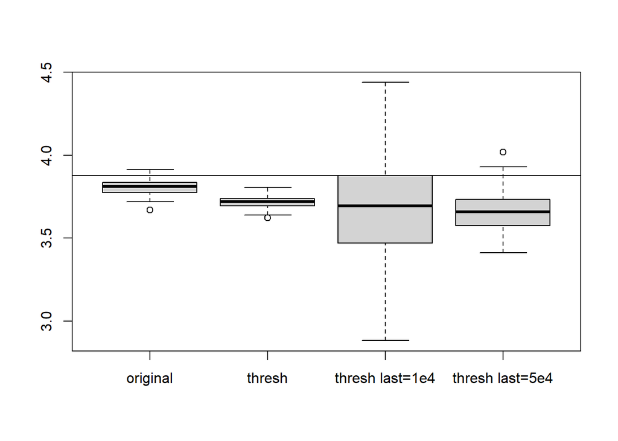

```r
var_fit_truth <- function(phi,omega)
{

  p <- dim(phi)[2]
  Inv.IPhi <- qr.solve(diag(1,p) - phi)
  V <- matrix(qr.solve(diag(1, p^2) - kronecker(phi, phi))%*%as.numeric(omega), nrow = p, ncol = p)
  Sigma <- Inv.IPhi%*%V + V%*%t(Inv.IPhi) - V
  Gamma <- - ( Inv.IPhi %*% Inv.IPhi %*% phi %*% V + V %*% t(phi) %*% t(Inv.IPhi) %*% t(Inv.IPhi) )
  return(list(Sigma = Sigma, Gamma = Gamma))
}

p <- 20
reps <- 1e2
N <- 1e6

A <- matrix(rnorm(p^2), ncol = p, nrow = p)
B <-  A %*% t(A)
Phi0 <- B/(max(eigen(B)$values) + .001)
phi <- 0.9 * Phi0
omega <- diag(p)
var_truth <- var_fit_truth(phi = phi, omega = omega)
const_truth = (sum(diag(var_truth$Gamma)^2)/(sum(diag(var_truth$Sigma)^2)))^(1/3)

OG_bs = numeric(reps)
bs_thresh_cpp = numeric(reps)
bs_thresh_cpp_last_1e4 = numeric(reps)
bs_thresh_cpp_last_5e4 = numeric(reps)

for(i in 1:reps)  {
  if(i %% (reps/10) == 0) print(i)
  chain <-  var1(p = p, phi = phi, nsim = N, omega = omega)
  OG_bs[i] = batchSize_const(chain)
  bs_thresh_cpp[i] = batchSize_threshold_cpp_const(chain)
  bs_thresh_cpp_last_1e4[i] = batchSize_threshold_cpp_last_const(chain, last_size = 1e4)
  bs_thresh_cpp_last_5e4[i] = batchSize_threshold_cpp_last_const(chain, last_size = 5e4)
}


boxplot(OG_bs, bs_thresh_cpp, bs_thresh_cpp_last_1e4, bs_thresh_cpp_last_5e4, names = c("original", "thresh", "thresh last=1e4", "thresh last=5e4"))
abline(h=const_truth)
```

```r
chain <-  var1(p = p, phi = phi, nsim = N, omega = omega)
benchmark(replications = 10, batchSize_const(chain), batchSize_threshold_cpp_const(chain), batchSize_threshold_cpp_last_const(chain, last_size = 1e4), batchSize_threshold_cpp_last_const(chain, last_size = 5e4), columns = c("test", "replications", "elapsed", "relative"))
```

```
##                                                           test replications
## 1                                       batchSize_const(chain)           10
## 2                         batchSize_threshold_cpp_const(chain)           10
## 3 batchSize_threshold_cpp_last_const(chain, last_size = 10000)           10
## 4 batchSize_threshold_cpp_last_const(chain, last_size = 50000)           10
##   elapsed relative
## 1  191.61   68.924
## 2   22.38    8.050
## 3    2.78    1.000
## 4    2.93    1.054
```

### Spatio Temporal

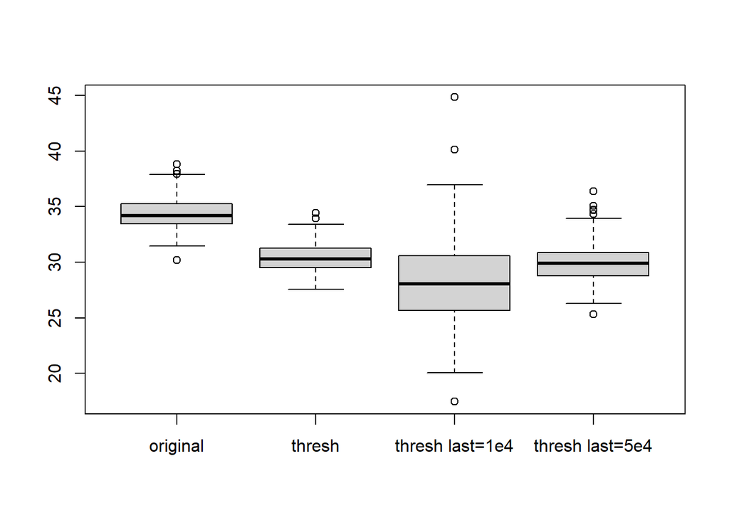

```r
N = 1e5
reps = 1e2
OG_bs = numeric(reps)
bs_thresh_cpp = numeric(reps)
bs_thresh_cpp_last_1e4 = numeric(reps)
bs_thresh_cpp_last_5e4 = numeric(reps)

for(i in 1:reps)  {
  if(i %% (reps/10) == 0) print(i)
  chain <- spatio_temp(N = N, verbose = FALSE)
  OG_bs[i] = batchSize_const(chain)
  bs_thresh_cpp[i] = batchSize_threshold_cpp_const(chain)
  bs_thresh_cpp_last_1e4[i] = batchSize_threshold_cpp_last_const(chain, last_size = 1e4)
  bs_thresh_cpp_last_5e4[i] = batchSize_threshold_cpp_last_const(chain, last_size = 5e4)
}


boxplot(OG_bs, bs_thresh_cpp, bs_thresh_cpp_last_1e4, bs_thresh_cpp_last_5e4, names = c("original", "thresh", "thresh last=1e4", "thresh last=5e4"))
```

```r
chain <- spatio_temp(N = N, verbose = FALSE)
benchmark(replications = 10, batchSize_const(chain), batchSize_threshold_cpp_const(chain), batchSize_threshold_cpp_last_const(chain, last_size = 1e4), batchSize_threshold_cpp_last_const(chain, last_size = 5e4), columns = c("test", "replications", "elapsed", "relative"))
```

```
##                                                           test replications
## 1                                       batchSize_const(chain)           10
## 2                         batchSize_threshold_cpp_const(chain)           10
## 3 batchSize_threshold_cpp_last_const(chain, last_size = 10000)           10
## 4 batchSize_threshold_cpp_last_const(chain, last_size = 50000)           10
##   elapsed relative
## 1  252.17   38.266
## 2   38.01    5.768
## 3    6.59    1.000
## 4   20.77    3.152
```

### EEL

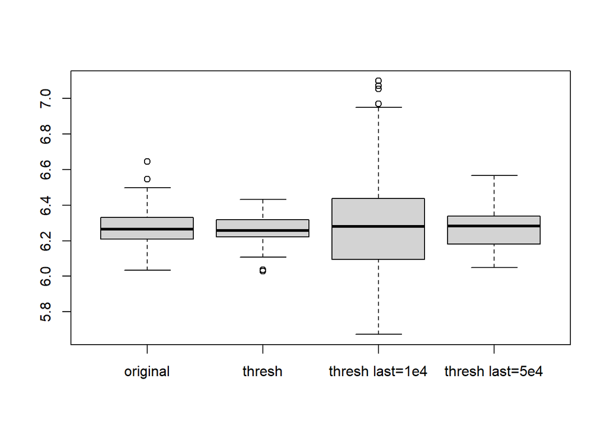

```r
data(Anguilla_train)
N = 1e5
reps = 1e2
random <- sample(1:1e6, reps)

OG_bs = numeric(reps)
bs_thresh_cpp = numeric(reps)
bs_thresh_cpp_last_1e4 = numeric(reps)
bs_thresh_cpp_last_5e4 = numeric(reps)

for(i in 1:reps)  {
  if(i %% (reps/10) == 0) print(i)
  chain <- chain <- MCMClogit(formula = Angaus~ 1 + . , data = dat, seed = random[i], burnin = 0, mcmc = N, thin = 1, B0 = 1/100, tune = .8)
  OG_bs[i] = batchSize_const(chain)
  bs_thresh_cpp[i] = batchSize_threshold_cpp_const(chain)
  bs_thresh_cpp_last_1e4[i] = batchSize_threshold_cpp_last_const(chain, last_size = 1e4)
  bs_thresh_cpp_last_5e4[i] = batchSize_threshold_cpp_last_const(chain, last_size = 5e4)
}


boxplot(OG_bs, bs_thresh_cpp, bs_thresh_cpp_last_1e4, bs_thresh_cpp_last_5e4, names = c("original", "thresh", "thresh last=1e4", "thresh last=5e4"))
```

```r
chain <- MCMClogit(formula = Angaus~ 1 + . , data = dat, seed = random[1], burnin = 0, mcmc = N, thin = 1, B0 = 1/100, tune = .8)
benchmark(replications = 10, batchSize_const(chain), batchSize_threshold_cpp_const(chain), batchSize_threshold_cpp_last_const(chain, last_size = 1e4), batchSize_threshold_cpp_last_const(chain, last_size = 5e4), columns = c("test", "replications", "elapsed", "relative"))
```

```
##                                                           test replications
## 1                                       batchSize_const(chain)           10
## 2                         batchSize_threshold_cpp_const(chain)           10
## 3 batchSize_threshold_cpp_last_const(chain, last_size = 10000)           10
## 4 batchSize_threshold_cpp_last_const(chain, last_size = 50000)           10
##   elapsed relative
## 1    4.78   15.933
## 2    0.93    3.100
## 3    0.30    1.000
## 4    0.61    2.033
```

As a final update to the package, we suggest adding a Boolean option fast to the batchSize() function. Setting fast = TRUE will call the cpp implementation with thresholding using the last 5e4 samples for acf calculation. Setting fast = FALSE will call the cpp implementation with thresholding using the entire chain for acf calculation. This update will balance speed with quality, improving remarkably on the existing implementation with only reasonable under-estimation.